# Session 6 - APIs (1)

5. Juni 2018

## Syllabus

Session 1 - R and RStudio

Session 2 - Data Typen und erste Befehle

Session 3 - Daten einlesen und speichern

Session 4 - Einfache Analyse (numerisch)

Session 5 - Visualisierung

`Session 6 & 7 - Application Programming Interfaces (APIs)`

Session 8 - Introduction to Web Scraping

Session 9 - Intorduction to Text Mining

## Agenda

1. Missing Values
2. Datenformate
3. Aufgaben
4. Was sind in APIs?
5. Aufgaben
6. OpenStreetMap API
7. Aufgaben

## Missing values

## Missing values (1)

```r
# löschen aller Zeilen, die mindestens ein NA haben
gtdb_complete <- na.omit(gtdb)
```

**Obacht:**

Bias Gefahr! Es ist möglich, dass Werte auf Grund einer Drittvariablen nicht beobachtet werden können. Normalerweise sollten fehlende Observationen genau untersucht und begründet werden.

## Datenformate

## JSON (1)

```json
[
  {
    "name": "Batman",
    "age": 99
  },
  {
    "name": "Robin",
    "age": 101
  }
]
```

## JSON (2)

```r
# parsing (lesen) json
library(jsonlite)
json <- readLines("batman.json")
parsed_json <- fromJSON(json)
```

```
##     name age
## 1 Batman  99
## 2  Robin 101
```

## XML (1)

```xml
<persons>
  <person name="Batman" age="99"></person>
  <person name="Robin" age="102"></person>
</persons>
```

## XML (2)

```r
# parsing (lesen) xml
library(xml2)
xml <- readLines("batman.xml")
parsed_xml <- read_xml(xml)
parsed_persons <- xml_find_all(parsed_xml, "//person")
parsed_text <- xml_attr(parsed_persons, "name")
```

```
## [1] "Batman" "Robin"
```

## Aufgaben

Textdateien können mit Hilfe des Befehls `readLines()` eingelesen werden. Die Funktion nimmt als Argument einen Dateipfad oder eine URL.

## Was sind APIs?

## Was sind APIs? (1)

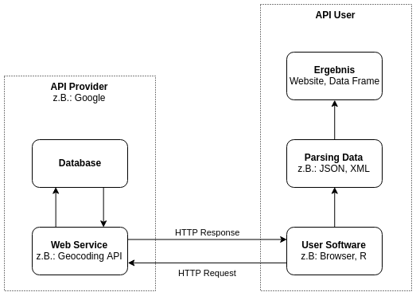

## Was sind APIs? (2)

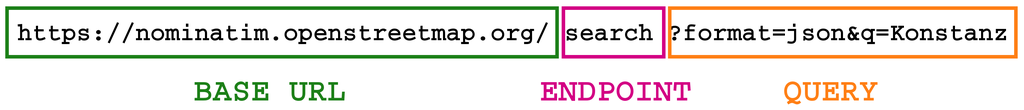

**BASE URL** (Stammurl): Wer bietet den Service an?

**ENDPOINT** (Endpunkt): Welchen Service möchtest du nutzten?

**PARAMETER** (Query): Auf welche Daten möchtest du zugreifen? Wie sollen die Daten gefiltert werden?

## Aufgaben

Unter https://wiki.openstreetmap.org/wiki/Nominatim findest du die Dokumentation der OpenStreetMap Nominatim API. Du kannst die Aufgaben mit Hilfe des Browsers lösen.

1. Welche Koordinaten hat die Universität Konstanz?
2. Zu welchem `County` gehört die Universität Harvard?
3. Die API kann sowohl die Daten im `JSON` und `XML` Format ausgeben. Wie kann man das Format ändern? Welches Format ist besser?

## APIs in R

## OSM Nominatim (1)

**Wir benutzen OpenStreetMap, da der Google Map Service einen Key benötigt.**

```r
# Addresse zu Koordinaten
osm_geocoding()
# Koordinaten zu Addresse
osm_reverse_geocoding()
```

Die Funktionen sind nicht in Base R verfügbar, sondern müssen aus dem Script `openstreetmap.r` geladen werden.

```r
source("openstreetmap.r")
```

## OSM Nominatim (2)

```r
# Koordinaten von Konstanz
coordinates_kn <- osm_geocoding("Konstanz")
coordinates_kn[ , 6:7]
```

```
##         lat       lon
## 1 47.659216 9.1750718
```

```r
# Ort an den Koordinaten Lat, Lon
lat <- 38.897096
lon <- -77.036545
secret_place <- osm_reverse_geocoding(lat, lon)
secret_place[ , 1:3]
```

```
##      building house_number                    pedestrian
## 1 White House         1600 Pennsylvania Avenue Northwest
```

## Aufgaben

Erstelle ein Sample mit allen vollständigen Observationen aus dem Jahr **2012**. Speicher diesen Datensatz in `gtdb_2012_complete`.

1. Erstelle eine leere Spalte `country` in dem neuen Datensatz.
2. Ermittle den **country_code** für jede Observation mit Hilfe von `osm_reverse_geocoding()`. **Obacht:** Diese Funktion ist nicht vektorisiert. Die Ausführung kann sehr, sehr lange dauern.